# Career Batting Average and Cooperstown

# Introduction

In this document, we examine the relationship between *career batting average* and *a baseball player’s chances of getting into the [hall of fame](https://baseballhall.org/)*, which is located in [Cooperstown, New York](https://en.wikipedia.org/wiki/Cooperstown,_New_York).

We will use [Sean Lahaman’s](http://www.seanlahman.com/baseball-archive/statistics/) data as hosted [on Kaggle](https://www.kaggle.com/seanlahman/the-history-of-baseball).

We restrict our analysis to players who played in over 1,500 games over the course of their career.

Then we may phrase our research question as follows: *historically speaking, if a player had a long career, then how did their batting average influence their probability of getting into the hall of fame?*

# Import

We will use the `batting.csv` file to get some career offensive stats for players with over 1,500 games.

```r
batting <- read_csv("../Data/batting.csv", col_types = cols())
dat <-
  batting %>%
  group_by(player_id) %>%
  summarize(g = sum(g), ab = sum(ab), h = sum(h)) %>%
  mutate(avg = h/ab) %>%
  filter(g > 1500)
```

We combine this with some player information (name and date of final game) found in `player.csv`.

```r
player <- read_csv("../Data/player.csv", col_types = cols())
dat <-
  player %>%
  select(player_id, name_first, name_last, final_game) %>%
  mutate(name = paste(name_first, name_last)) %>%
  select(player_id, name, final_game) %>%
  inner_join(dat, by = "player_id")
```

We use `hall_of_fame.sv` to see which players are in Cooperstown.

```r
hof <- read_csv("../Data/hall_of_fame.csv")
dat <-
  hof %>%
  filter(inducted == "Y", category == "Player") %>%
  select(player_id, inducted) %>%
  right_join(dat, by = "player_id") %>%
  replace_na(list(inducted = "N"))%>%
  mutate(inducted = factor(inducted))
```

# Explore

How up to date is our data?

We can see that the game stats are current through the 2015 season.

```r
dat %>% arrange(desc(final_game)) %>% slice(1:5)
```

```
## # A tibble: 5 x 8
##   player_id inducted name           final_game     g    ab     h   avg
##   <chr>     <fct>    <chr>          <date>     <dbl> <dbl> <dbl> <dbl>
## 1 beltrad01 N        Adrian Beltre  2015-10-04  2567  9712  2767 0.285
## 2 beltrca01 N        Carlos Beltran 2015-10-04  2306  8749  2454 0.280
## 3 byrdma01  N        Marlon Byrd    2015-10-04  1539  5464  1503 0.275
## 4 canoro01  N        Robinson Cano  2015-10-04  1687  6555  2015 0.307
## 5 crawfca02 N        Carl Crawford  2015-10-04  1686  6574  1916 0.291
```

Meanwhile, the hall of fame information is current through the year 2016.

```r
hof  %>% arrange(desc(yearid))%>% slice(1:5)
```

```
## # A tibble: 5 x 9
##   player_id yearid votedby ballots needed votes inducted category
##   <chr>      <dbl> <chr>     <dbl>  <dbl> <dbl> <chr>    <chr>
## 1 griffke02   2016 BBWAA       440    330   437 Y        Player
## 2 piazzmi01   2016 BBWAA       440    330   365 Y        Player
## 3 bagweje01   2016 BBWAA       440    330   315 N        Player
## 4 raineti01   2016 BBWAA       440    330   307 N        Player
## 5 hoffmtr01   2016 BBWAA       440    330   296 N        Player
## # ... with 1 more variable: needed_note <chr>
```

According to the [rules for election](https://baseballhall.org/hall-of-famers/rules/bbwaa-rules-for-election), players who were still playing after 2010 would not be eligible for induction. We can see this reflected in our data with the following visualization.

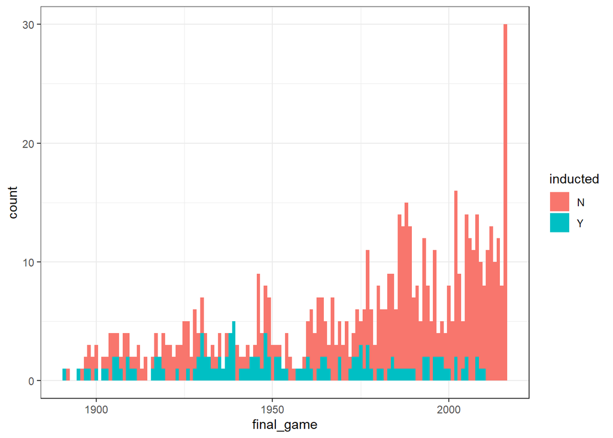

```r
most_recent <- dat %>% pull(final_game) %>% max() %>% str_sub(start = 1, end = 4)
most_distant <- dat %>% pull(final_game) %>% min() %>% str_sub(start = 1, end = 4)
date_range <- as.numeric(most_recent) - as.numeric(most_distant) + 1

dat %>%
  ggplot(mapping = aes(x = final_game, fill = inducted)) +
  geom_histogram(bins = date_range) +
  theme_bw()
```

Therefore, we restrict our attention to players who ended their careers before 2011.

```r
dat <- dat %>% filter(final_game <= "2010-12-31")
```

# Model

We fit a logistic regression model.

```r
fit <- glm(formula = inducted ~ avg, data = dat, family = "binomial")
```

We can visualize the model (along with the observed data) as follows.

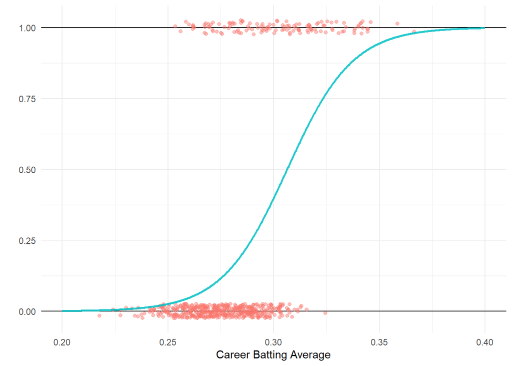

```r
plot_domain <- seq(from = 0.2, to = 0.4, length.out = 1000)
plot_range <- predict(fit, newdata = tibble(avg = plot_domain), type = "response")
plot_data <- tibble(x = plot_domain, y = plot_range)

p <-
  ggplot() +
  geom_hline(yintercept = 1) +
  geom_hline(yintercept = 0) +
  # geom_hline(yintercept = 0.5, linetype = "dashed") +
  # geom_vline(xintercept = 0.3065, linetype = "dashed") +
  geom_jitter(data = dat,
              mapping = aes(x = avg, y = as.numeric(inducted)-1),
              height = 0.025, alpha = 0.45, color = "#F8766D") +
  geom_line(data = plot_data,
            mapping = aes(x=x, y= y),
            color = "#00BFC4",size = 1, alpha = 0.85) +
  theme_minimal() +
  labs(x = "Career Batting Average", y = "")

p
```

The red points in the plot represent our observed outcomes (i.e., how the world actually is):

- X axis: career batting average
- Y axis : Hall of Fame Status (0 = not in HOF, 1 = in HOF)

Meanwhile, the blue curve represents the predictions of the model (i.e., how the model sees the world):

- X axis: career batting average.
- Y axis : probability (as predicted by the model) of getting into the HOF, as a function of career batting average.

According to our model, if a player with over 1,500 games ends up with a batting average of .306, then they have a 50% chance of being inducted into the baseball hall of fame.

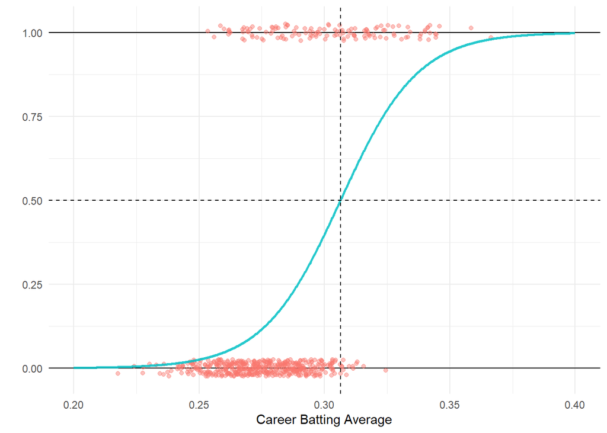

```r
beta_0 <- fit$coefficients[1]
beta_1 <- fit$coefficients[2]
class_boundary <- -beta_0 / beta_1
p +
  geom_hline(yintercept = 0.5, linetype = "dashed") +
  geom_vline(xintercept = class_boundary, linetype = "dashed")
```

# Conclusion

If we reduce our model to the rule “if a player with over 1,500 games ends up with a batting average of .306, then they will be inducted into the baseball hall of fame”, then this rule works on 85% of the training cases.

```r
predicted <- predict(fit, type = "response")
predictedBool <- predicted > 0.5
observed <- dat %>% mutate(observed = inducted == "Y") %>% pull(observed)
tibble(predicted = factor(predictedBool),
       observed = factor(observed),
       correct = as.numeric(predicted == observed)) %>%
  summarize(mean(correct))
```

```
## # A tibble: 1 x 1
##   `mean(correct)`
##             <dbl>
## 1           0.854
```

In this sense, our model reduces the complexity of the world to an extremely simple heuristic.